# Lifestyle, Socioeconomic Circumstances, and Healthcare Access Associated with Self-Reported Diabetes: An Analysis of BRFSS 2025

BMIN5030 Final Project

Author

Qijia Ge

Use this template to complete your project throughout the course. Your Final Project presentation will be based on the contents of this document. Replace the title/name above and text below with your own, but keep the headers. Feel free to change the theme and other display settings, although this is not required.

## 1 1. Overview

Give a brief a description of your project and its goal(s), what data you are using to complete it, and what two faculty/staff in different fields you have spoken to about your project with a brief summary of what you learned from each person. Include a link to your final project GitHub repository.

This project will use the 2025 Behavioral Risk Factor Surveillance System (BRFSS) https://www.cdc.gov/brfss/annual_data/annual_2025.html to investigate whether lifestyle, socioeconomic, and healthcare-access characteristics improve classification of self-reported diagnosed diabetes beyond age, sex, and body mass index. Logistic regression will provide an interpretable baseline, while XGBoost will assess whether nonlinear relationships and interactions improve predictive performance. Particular attention will be given to potentially less obvious predictors, including sleep duration, healthcare affordability, and having a regular healthcare provider, to assess their additional predictive value.

**Planned consultation topics:** Feedback will be sought on selecting and interpreting these less obvious features, establishing appropriate baseline and advanced models, and evaluating performance while avoiding data leakage. These are proposed discussion topics with the faculty/staff this week rather than completed feedback.

**GitHub repository:** [https://github.com/JustinGE/BMIN5030_Final_Project.git]

## 2 2. Introduction

Describe the problem addressed, its significance, and some background to motivate the problem. This should extend what is in the Section 1.

Explain why your problem is interdisciplinary, what fields can contribute to its understanding, and incorporate background related to what you learned from meeting with faculty/staff.

Diabetes is a major public health challenge: the World Health Organization estimates that the number of people living with diabetes increased from approximately 200 million in 1990 to 830 million in 2022. Diabetes can also lead to serious complications, including kidney failure, blindness, heart attacks, stroke, and lower-limb amputation [1]. Understanding how everyday behaviors and social circumstances relate to diagnosed diabetes may help inform prevention and efforts to address health disparities. This project will use BRFSS 2025 to investigate whether lifestyle, socioeconomic, and healthcare-access characteristics improve classification of self-reported diagnosed diabetes beyond age, sex, and body mass index. Particular attention will be given to sleep duration, healthcare affordability, and having a regular healthcare provider. Because the data are cross-sectional and the outcome reflects a reported diagnosis, findings will be interpreted as associations that may reflect both disease occurrence and opportunities for detection.

This project integrates epidemiology, social and behavioral science, health services research, and machine learning. Epidemiology provides approaches for interpreting survey data and accounting for confounding, while social and behavioral science helps explain how individual circumstances may relate to health behaviors. Health services research contributes an understanding of how access to care may influence diagnosis, and machine learning enables comparisons between interpretable logistic regression and XGBoost models that capture nonlinear relationships and interactions. Planned faculty/staff consultations will help refine the selection of less obvious predictors and establish appropriate model comparisons and evaluation strategies, including safeguards against data leakage. Specific feedback and its influence on the project will be incorporated after these consultations.

[1] “Diabetes.” Accessed: Nov. 04, 2026. [Online]. Available: https://www.who.int/news-room/fact-sheets/detail/diabetes

## 3 3. Methods

### 3.1 3.1 Data Preprocessing

#### 3.1.1 3.1.1 Importing and inspecting the data

We imported the full 2025 Behavioral Risk Factor Surveillance System (BRFSS) public-use dataset before selecting variables for analysis. Each row represents a survey respondent. The columns include survey responses, calculated variables, and information about the survey design. We first checked the size of the dataset and reviewed the names and descriptions of its columns to understand what information was available.

```r
list.files(
  "/Users/justinge/Downloads/BMIN 5030/Final Project/BMIN 5030 Final Project",
  pattern = "LLCP2025.XPT",
  ignore.case = TRUE,
  recursive = TRUE
)
```

```
[1] "LLCP2025.XPT "
```

```r
brfss_path <- "LLCP2025.XPT "
file.exists(brfss_path)
```

```
[1] TRUE
```

```r
brfss_full <- haven::read_xpt(brfss_path)

data.frame(
  Respondents = nrow(brfss_full),
  Columns = ncol(brfss_full)
)
```

```
  Respondents Columns
1      356158     283
```

```r
column_inventory <- data.frame(
  Variable = names(brfss_full),
  Description = vapply(brfss_full, function(column) {
    label <- attr(column, "label")
    if (is.null(label)) "" else label
  }, character(1))
)

knitr::kable(
  column_inventory,
  row.names = FALSE,
  caption = "Variables in the imported 2025 BRFSS dataset"
)
```

Variables in the imported 2025 BRFSS dataset

| Variable | Description |
| --- | --- |
| _STATE | STATE FIPS CODE |
| FMONTH | FILE MONTH |
| IDATE | INTERVIEW DATE |
| IMONTH | INTERVIEW MONTH |
| IDAY | INTERVIEW DAY |
| IYEAR | INTERVIEW YEAR |
| DISPCODE | FINAL DISPOSITION |
| SEQNO | ANNUAL SEQUENCE NUMBER |
| _PSU | PRIMARY SAMPLING UNIT |
| CTELENM1 | CORRECT TELEPHONE NUMBER? |
| PVTRESD1 | PRIVATE RESIDENCE? |
| COLGHOUS | DO YOU LIVE IN COLLEGE HOUSING? |
| STATERE1 | RESIDENT OF STATE |
| CELPHON1 | CELLULAR TELEPHONE |
| LADULT1 | ARE YOU 18 YEARS OF AGE OR OLDER? |
| NUMADULT | NUMBER OF ADULTS IN HOUSEHOLD |
| RESPSLC1 | RESPONDENT SELECTION |
| LANDSEX4 | ARE YOU MALE OR FEMALE? |
| SAFETIME | SAFE TIME TO TALK? |
| CTELNUM1 | CORRECT PHONE NUMBER? |
| CELLFON5 | IS THIS A CELL PHONE? |
| CADULT1 | ARE YOU 18 YEARS OF AGE OR OLDER? |
| CELLSEX4 | ARE YOU MALE OR FEMALE? |
| PVTRESD3 | DO YOU LIVE IN A PRIVATE RESIDENCE? |
| CCLGHOUS | DO YOU LIVE IN COLLEGE HOUSING? |
| CSTATE1 | DO YOU CURRENTLY LIVE IN ____(STATE)___ |
| LANDLINE | DO YOU ALSO HAVE A LANDLINE TELEPHONE? |
| HHADULT | NUMBER OF ADULTS IN HOUSEHOLD |
| SEXVAR | SEX OF RESPONDENT |
| GENHLTH | GENERAL HEALTH |

[output cut: 253 more lines]

The imported 2025 BRFSS dataset contained 356,158 survey records and 283 variables. Each row represents one respondent. The columns include direct survey responses, calculated variables, and information used to describe the survey design. The table below lists each variable and its description as stored in the data file.

```r
preview_columns <- c("DIABETE4", "_AGEG5YR", "SEXVAR", "_BMI5", "EXERANY2")

knitr::kable(
  head(brfss_full[, preview_columns]),
  row.names = FALSE,
  caption = "Example respondent records before preprocessing"
)
```

Example respondent records before preprocessing

| DIABETE4 | _AGEG5YR | SEXVAR | _BMI5 | EXERANY2 |
| --- | --- | --- | --- | --- |
| 3 | 11 | 2 | 3079 | 1 |
| 1 | 13 | 2 | 1966 | 1 |
| 1 | 10 | 2 | 3320 | 2 |
| 1 | 13 | 1 | 2980 | 2 |
| 3 | 9 | 1 | 2846 | 1 |
| 3 | 13 | 1 | 2647 | 1 |

#### 3.1.2 3.1.2 Inspecting the diabetes outcome

We first examined `DIABETE4`, which records whether respondents report having been told by a healthcare professional that they have diabetes. We tabulated the original responses before creating a binary outcome because the survey distinguishes a diabetes diagnosis from pregnancy-only diabetes, prediabetes, and uncertain or missing responses.

```r
diabetes_response <- factor(
  brfss_full$DIABETE4,
  levels = c(1, 2, 3, 4, 7, 9),
  labels = c(
    "Yes",
    "Yes, only during pregnancy",
    "No",
    "Prediabetes or borderline diabetes",
    "Don't know / not sure",
    "Refused"
  )
)

diabetes_counts <- as.data.frame(
  table(diabetes_response, useNA = "always")
)
names(diabetes_counts) <- c("Survey response", "Respondents")
diabetes_counts$`Survey response` <- as.character(diabetes_counts$`Survey response`)
diabetes_counts$`Survey response`[is.na(diabetes_counts$`Survey response`)] <- "Missing"

knitr::kable(
  diabetes_counts,
  caption = "Unweighted counts of original diabetes survey responses"
)
```

Unweighted counts of original diabetes survey responses

| Survey response | Respondents |
| --- | --- |
| Yes | 51827 |
| Yes, only during pregnancy | 2671 |
| No | 290712 |
| Prediabetes or borderline diabetes | 10166 |
| Don’t know / not sure | 580 |
| Refused | 196 |
| Missing | 6 |

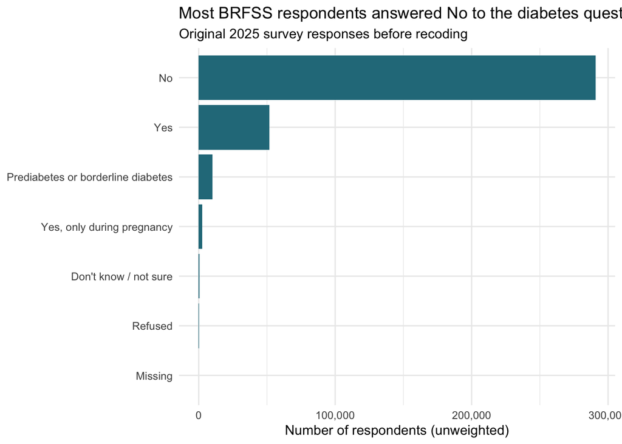

```r
ggplot2::ggplot(
  diabetes_counts,
  ggplot2::aes(
    x = Respondents,
    y = reorder(`Survey response`, Respondents)
  )
) +
  ggplot2::geom_col(fill = "#287A8A") +
  ggplot2::scale_x_continuous(labels = scales::label_comma()) +
  ggplot2::labs(
    title = "Most BRFSS respondents answered No to the diabetes question",
    subtitle = "Original 2025 survey responses before recoding",
    x = "Number of respondents (unweighted)",
    y = NULL
  ) +
  ggplot2::theme_minimal()
```

#### 3.1.3 3.1.3 Defining the binary outcome

We recoded `DIABETE4` into a binary outcome indicating whether respondents reported a diabetes diagnosis outside pregnancy. A response of “Yes” was coded as 1, while “No,” pregnancy-only diabetes, and prediabetes or borderline diabetes were coded as 0. Uncertain, refused, and missing responses were coded as missing and excluded from the modeling sample.

```r
brfss_model <- brfss_full |>
  dplyr::mutate(
    diabetes = dplyr::case_when(
      DIABETE4 == 1 ~ 1L,
      DIABETE4 %in% c(2, 3, 4) ~ 0L,
      TRUE ~ NA_integer_
    )
  )

# Check the new outcome before removing any rows.
table(brfss_model$diabetes, useNA = "always")
```

```
     0      1   <NA>
303549  51827    782
```

```r
# Keep respondents with a known outcome.
brfss_model <- brfss_model |>
  dplyr::filter(!is.na(diabetes))

nrow(brfss_model)
```

```
[1] 355376
```

**3.1.4 Selecting candidate predictors**

We created a working dataset containing the binary diabetes outcome and grouped candidate predictors into four categories: baseline characteristics, lifestyle, socioeconomic circumstances, and healthcare access. These groups allow us to test whether the additional variables improve classification beyond age group, sex, and BMI. Survey design variables were retained separately from the predictors. All respondents with a known diabetes outcome were kept at this stage; we examined predictor coding and missingness before applying any further exclusions.

```r
analysis_columns <- c(
  "diabetes",
  "_AGEG5YR", "SEXVAR", "_BMI5",                  # Baseline
  "EXERANY2", "_SMOKER3", "SLEPTIM1",
  "ALCDAY4", "_FRUTSU1", "_VEGESU1",              # Lifestyle
  "INCOME3", "EDUCA", "EMPLOY1", "RENTHOM1",      # Socioeconomic
  "PRIMINS2", "PERSDOC3", "MEDCOST1", "CHECKUP1", # Healthcare access
  "_LLCPWT", "_STSTR", "_PSU"                     # Survey design only
)

brfss_analysis <- brfss_model[, analysis_columns]
dim(brfss_analysis)
```

```
[1] 355376     21
```

```r
predictor_names <- setdiff(
  analysis_columns,
  c("diabetes", "_LLCPWT", "_STSTR", "_PSU")
)

predictor_audit <- data.frame(
  Variable = predictor_names,
  Distinct_recorded_values = vapply(
    brfss_analysis[predictor_names],
    function(x) length(unique(x[!is.na(x)])),
    integer(1)
  ),
  Raw_blanks = colSums(is.na(brfss_analysis[predictor_names])),
  row.names = NULL
)

knitr::kable(predictor_audit, caption = "Initial audit of candidate predictors")
```

Initial audit of candidate predictors

| Variable | Distinct_recorded_values | Raw_blanks |
| --- | --- | --- |
| _AGEG5YR | 14 | 0 |
| SEXVAR | 2 | 0 |
| _BMI5 | 3972 | 32312 |
| EXERANY2 | 4 | 0 |
| _SMOKER3 | 5 | 0 |
| SLEPTIM1 | 26 | 22661 |
| ALCDAY4 | 40 | 23499 |
| _FRUTSU1 | 610 | 46212 |
| _VEGESU1 | 1914 | 53244 |
| INCOME3 | 13 | 7108 |
| EDUCA | 7 | 0 |
| EMPLOY1 | 9 | 2675 |
| RENTHOM1 | 5 | 3 |
| PRIMINS2 | 13 | 0 |
| PERSDOC3 | 5 | 0 |
| MEDCOST1 | 4 | 0 |
| CHECKUP1 | 7 | 0 |

#### 3.1.4 3.1.5 Cleaning the baseline predictors

```r
brfss_clean <- brfss_analysis |>
  dplyr::mutate(
    age_group = factor(
      `_AGEG5YR`,
      levels = 1:13,
      labels = c(
        "18–24", "25–29", "30–34", "35–39", "40–44", "45–49",
        "50–54", "55–59", "60–64", "65–69", "70–74", "75–79", "80+"
      )
    ),
    sex = factor(
      SEXVAR,
      levels = c(1, 2),
      labels = c("Male", "Female")
    ),
    bmi = as.numeric(`_BMI5`) / 100
  )

table(brfss_clean$age_group, useNA = "always")
```

```
18–24 25–29 30–34 35–39 40–44 45–49 50–54 55–59 60–64 65–69 70–74 75–79   80+
23170 17966 19280 21402 22951 21979 23092 25963 32535 37055 35618 31021 36800
 <NA>
 6544
```

```r
table(brfss_clean$sex, useNA = "always")
```

```
  Male Female   <NA>
168026 187350      0
```

```r
summary(brfss_clean$bmi)
```

```
   Min. 1st Qu.  Median    Mean 3rd Qu.    Max.     NAs
  12.02   24.07   27.41   28.47   31.62   98.43   32312
```

```r
nrow(brfss_clean)
```

```
[1] 355376
```

We converted age-group and sex codes into labeled categories and treated the code for unknown age as missing. We divided the CDC-derived BMI values by 100 to restore their original scale. These transformations created the three baseline predictors while retaining all respondents at this stage.

#### 3.1.5 3.1.6 Cleaning the lifestyle predictors

```r
table(brfss_analysis$SLEPTIM1, useNA = "always")
```

```
    1     2     3     4     5     6     7     8     9    10    11    12    13
  107   498  1816  8358 21593 70315 99177 97810 16644  8308   516  2091   116
   14    15    16    17    18    19    20    21    22    23    24    77    99
  255   202   237    23   103     7    62     8     7     8    25  3531   898
 <NA>
22661
```

```r
brfss_clean <- brfss_clean |>
  dplyr::mutate(
    sleep_hours = dplyr::if_else(
      SLEPTIM1 %in% 1:24,
      as.numeric(SLEPTIM1),
      NA_real_
    )
  )

# Verify the recode
table(brfss_clean$sleep_hours, useNA = "always")
```

```
    1     2     3     4     5     6     7     8     9    10    11    12    13
  107   498  1816  8358 21593 70315 99177 97810 16644  8308   516  2091   116
   14    15    16    17    18    19    20    21    22    23    24  <NA>
  255   202   237    23   103     7    62     8     7     8    25 27090
```

We retained reported sleep durations of 1–24 hours per day. Responses coded as “don’t know” or “refused” were set to missing, along with blank responses. We retained these respondents at this stage so that we could assess missingness across all selected predictors before deciding how to handle incomplete records.

```r
# Inspect the original response codes.
table(brfss_clean$EXERANY2, useNA = "always")
```

```
     1      2      7      9   <NA>
272384  82052    647    293      0
```

```r
table(brfss_clean$`_SMOKER3`, useNA = "always")
```

```
     1      2      3      4      9   <NA>
 23955  10423  95925 204571  20502      0
```

```r
# Add the cleaned variables to the existing table.
brfss_clean <- brfss_clean |>
  dplyr::mutate(
    physical_activity = factor(
      EXERANY2,
      levels = c(2, 1),
      labels = c("No", "Yes")
    ),
    smoking_status = factor(
      `_SMOKER3`,
      levels = c(4, 3, 2, 1),
      labels = c("Never", "Former", "Current some days", "Current daily")
    )
  )

# Check the cleaned categories and confirm the row count.
table(brfss_clean$physical_activity, useNA = "always")
```

```
    No    Yes   <NA>
 82052 272384    940
```

```r
table(brfss_clean$smoking_status, useNA = "always")
```

```
            Never            Former Current some days     Current daily
           204571             95925             10423             23955
             <NA>
            20502
```

```r
nrow(brfss_clean)
```

```
[1] 355376
```

We recoded reported leisure-time physical activity in the past month as a yes/no variable and used the CDC-derived smoking status variable to distinguish never, former, and current smokers. We retained the distinction between daily and some-day smoking and set unknown responses to missing. No respondents were removed during this step.

```r
# Inspect the original alcohol codes and diet ranges.
table(brfss_clean$ALCDAY4, useNA = "always")
```

```
   101    102    103    104    105    106    107    201    202    203    204
 14509  11050   7879   3778   3643   1242   3977  28985  21102  11665   9170
   205    206    207    208    209    210    211    212    213    214    215
  7742   2912   2103   2370    217   4637     48   1207     77    447   3798
   216    217    218    219    220    221    222    223    224    225    226
   187     71    163     13   4347    160    131     53    157   2078    116
   227    228    229    230    777    888    999   <NA>
   184    702    196   9183   1852 168387   1339  23499
```

```r
summary(as.numeric(brfss_clean$`_FRUTSU1`))
```

```
   Min. 1st Qu.  Median    Mean 3rd Qu.    Max.     NAs
    0.0    50.0   100.0   152.7   200.0 19800.0   46212
```

```r
summary(as.numeric(brfss_clean$`_VEGESU1`))
```

```
   Min. 1st Qu.  Median    Mean 3rd Qu.    Max.     NAs
    0.0   104.0   157.0   228.1   224.0 39600.0   53244
```

```r
# Add the cleaned variables while keeping the original columns.
brfss_clean <- brfss_clean |>
  dplyr::mutate(
    alcohol_days_week = dplyr::case_when(
      ALCDAY4 %in% 101:107 ~ as.numeric(ALCDAY4) - 100,
      ALCDAY4 %in% 201:230 ~ (as.numeric(ALCDAY4) - 200) * 7 / 30,
      ALCDAY4 == 888 ~ 0,
      TRUE ~ NA_real_
    ),
    fruit_times_day = dplyr::if_else(
      `_FRUTSU1` %in% 0:99998,
      as.numeric(`_FRUTSU1`) / 100,
      NA_real_
    ),
    vegetable_times_day = dplyr::if_else(
      `_VEGESU1` %in% 0:99998,
      as.numeric(`_VEGESU1`) / 100,
      NA_real_
    )
  )

intake_vars <- c("alcohol_days_week", "fruit_times_day", "vegetable_times_day")

summary(brfss_clean[intake_vars])
```

```
 alcohol_days_week fruit_times_day   vegetable_times_day
 Min.   :0.0000    Min.   :  0.000   Min.   :  0.000
 1st Qu.:0.0000    1st Qu.:  0.500   1st Qu.:  1.040
 Median :0.0000    Median :  1.000   Median :  1.570
 Mean   :0.9789    Mean   :  1.527   Mean   :  2.281
 3rd Qu.:1.0000    3rd Qu.:  2.000   3rd Qu.:  2.240
 Max.   :7.0000    Max.   :198.000   Max.   :396.000
 NAs    :26690     NAs    :46212     NAs    :53244
```

```r
colSums(is.na(brfss_clean[intake_vars]))
```

```
  alcohol_days_week     fruit_times_day vegetable_times_day
              26690               46212               53244
```

```r
nrow(brfss_clean)
```

```
[1] 355376
```

We converted reported alcohol use frequency to days per week, retaining zero for respondents who reported no alcohol use in the past 30 days. We divided the CDC-derived fruit and vegetable totals by 100 to recover daily consumption frequencies. Unusable values were coded as missing, and all respondents were retained during this step.

```r
# Count values flagged as out of range before changing them.
diet_check <- data.frame(
  Predictor = c("Fruit intake", "Vegetable intake"),
  Missing_before = c(
    sum(is.na(brfss_clean$fruit_times_day)),
    sum(is.na(brfss_clean$vegetable_times_day))
  ),
  Above_CDC_threshold = c(
    sum(brfss_clean$fruit_times_day > 16, na.rm = TRUE),
    sum(brfss_clean$vegetable_times_day > 23, na.rm = TRUE)
  )
)

knitr::kable(diet_check, caption = "Missing and out-of-range diet values")
```

Missing and out-of-range diet values

| Predictor | Missing_before | Above_CDC_threshold |
| --- | --- | --- |
| Fruit intake | 46212 | 1108 |
| Vegetable intake | 53244 | 1732 |

```r
brfss_clean <- brfss_clean |>
  dplyr::mutate(
    fruit_times_day = replace(fruit_times_day, fruit_times_day > 16, NA_real_),
    vegetable_times_day = replace(
      vegetable_times_day, vegetable_times_day > 23, NA_real_
    )
  )

summary(brfss_clean[c("fruit_times_day", "vegetable_times_day")])
```

```
 fruit_times_day  vegetable_times_day
 Min.   : 0.000   Min.   : 0.000
 1st Qu.: 0.500   1st Qu.: 1.040
 Median : 1.000   Median : 1.570
 Mean   : 1.294   Mean   : 1.825
 3rd Qu.: 2.000   3rd Qu.: 2.210
 Max.   :16.000   Max.   :23.000
 NAs    :47320    NAs    :54976
```

We inspected the distributions of the converted dietary frequencies and found unusually high values. Using the CDC’s out-of-range thresholds, we set fruit intake above 16 times per day and vegetable intake above 23 times per day to missing. We retained the respondents and their other survey responses.

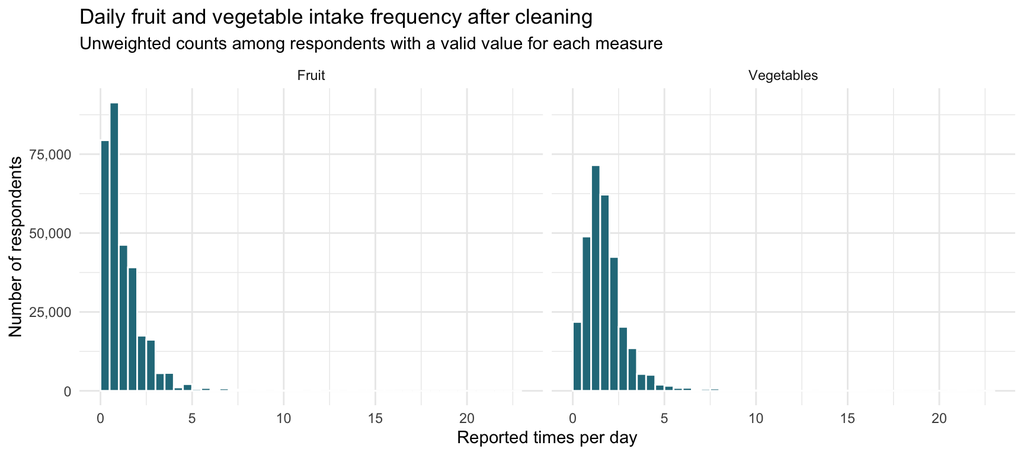

```r
diet_plot <- brfss_clean |>
  dplyr::select(fruit_times_day, vegetable_times_day) |>
  tidyr::pivot_longer(
    cols = dplyr::everything(),
    names_to = "food",
    values_to = "times_per_day",
    values_drop_na = TRUE
  ) |>
  dplyr::mutate(
    food = factor(
      food,
      levels = c("fruit_times_day", "vegetable_times_day"),
      labels = c("Fruit", "Vegetables")
    )
  )

ggplot2::ggplot(diet_plot, ggplot2::aes(x = times_per_day)) +
  ggplot2::geom_histogram(
    binwidth = 0.5, boundary = 0,
    fill = "#287A8A", color = "white"
  ) +
  ggplot2::facet_wrap(~ food, nrow = 1) +
  ggplot2::scale_y_continuous(labels = scales::label_comma()) +
  ggplot2::labs(
    title = "Daily fruit and vegetable intake frequency after cleaning",
    subtitle = "Unweighted counts among respondents with a valid value for each measure",
    x = "Reported times per day",
    y = "Number of respondents"
  ) +
  ggplot2::theme_minimal()
```

#### 3.1.6 3.1.7 Cleaning socioeconomic predictors

```r
socioeconomic_vars <- c("INCOME3", "EDUCA", "EMPLOY1", "RENTHOM1")

lapply(
  brfss_clean[socioeconomic_vars],
  function(x) table(x, useNA = "always")
)
```

```
$INCOME3
x
    1     2     3     4     5     6     7     8     9    10    11    77    99
 7685  7947 10257 15223 31624 37929 46279 39901 43378 21162 23355 29662 33866
 <NA>
 7108

$EDUCA
x
     1      2      3      4      5      6      9   <NA>
   484   6494  12968  91813  93789 147770   2058      0

$EMPLOY1
x
     1      2      3      4      5      6      7      8      9   <NA>
138804  30062   6941   8308  13866   9184 119634  21627   4275   2675

$RENTHOM1
x
     1      2      3      7      9   <NA>
243876  89697  18277    889   2634      3
```

```r
brfss_clean <- brfss_clean |>
  dplyr::mutate(
    income_group = factor(
      INCOME3,
      levels = 1:11,
      labels = c(
        "Under $10,000",
        "$10,000–<$15,000",
        "$15,000–<$20,000",
        "$20,000–<$25,000",
        "$25,000–<$35,000",
        "$35,000–<$50,000",
        "$50,000–<$75,000",
        "$75,000–<$100,000",
        "$100,000–<$150,000",
        "$150,000–<$200,000",
        "$200,000 or more"
      )
    ),
    education = factor(
      EDUCA,
      levels = 1:6,
      labels = c(
        "Never attended school / kindergarten only",
        "Grades 1–8",
        "Grades 9–11",
        "High school graduate / GED",
        "Some college / technical school",
        "College graduate"
      )
    ),
    employment = factor(
      EMPLOY1,
      levels = 1:8,
      labels = c(
        "Employed for wages",
        "Self-employed",
        "Out of work: 1 year or more",
        "Out of work: less than 1 year",
        "Homemaker",
        "Student",
        "Retired",
        "Unable to work"
      )
    ),
    housing_tenure = factor(
      RENTHOM1,
      levels = 1:3,
      labels = c("Own", "Rent", "Other arrangement")
    )
  )

clean_socioeconomic <- c(
  "income_group", "education", "employment", "housing_tenure"
)

lapply(
  brfss_clean[clean_socioeconomic],
  function(x) table(x, useNA = "always")
)
```

```
$income_group
x
     Under $10,000   $10,000–<$15,000   $15,000–<$20,000   $20,000–<$25,000
              7685               7947              10257              15223
  $25,000–<$35,000   $35,000–<$50,000   $50,000–<$75,000  $75,000–<$100,000
             31624              37929              46279              39901
$100,000–<$150,000 $150,000–<$200,000   $200,000 or more               <NA>
             43378              21162              23355              70636

$education
x
Never attended school / kindergarten only
                                      484
                               Grades 1–8
                                     6494
                              Grades 9–11
                                    12968
               High school graduate / GED
                                    91813
          Some college / technical school
                                    93789
                         College graduate
                                   147770
                                     <NA>
                                     2058

$employment
x
           Employed for wages                 Self-employed
                       138804                         30062
  Out of work: 1 year or more Out of work: less than 1 year
                         6941                          8308
                    Homemaker                       Student
                        13866                          9184
                      Retired                Unable to work
                       119634                         21627
                         <NA>
                         6950

$housing_tenure
x
              Own              Rent Other arrangement              <NA>
           243876             89697             18277              3526
```

```r
colSums(is.na(brfss_clean[clean_socioeconomic]))
```

```
  income_group      education     employment housing_tenure
         70636           2058           6950           3526
```

```r
nrow(brfss_clean)
```

```
[1] 355376
```

We converted household income, education, employment status, and housing tenure into labeled categorical predictors. Unknown, refused, and blank responses were treated as missing. Income brackets were retained as categories rather than converted to dollar amounts. No respondents were removed during this step.

After recoding, income had the highest missingness among these predictors (19.9%), compared with education (0.6%), employment (2.0%), and housing tenure (1.0%). We deferred decisions about incomplete records until all selected predictors had been cleaned.

#### 3.1.7 3.1.8 Cleaning Healthcare-access predictors

```r
healthcare_vars <- c("PRIMINS2", "PERSDOC3", "MEDCOST1", "CHECKUP1")

lapply(
  brfss_clean[healthcare_vars],
  function(x) table(x, useNA = "always")
)
```

```
$PRIMINS2
x
     1      2      3      4      5      6      7      8      9     10     77
116761  30021 116909    290  26651    117  14067   1045   8507   6830  10486
    88     99   <NA>
 18866   4826      0

$PERSDOC3
x
     1      2      3      7      9   <NA>
188738 121134  42069   2616    819      0

$MEDCOST1
x
     1      2      7      9   <NA>
 34426 319757    931    262      0

$CHECKUP1
x
     1      2      3      4      7      8      9   <NA>
290936  29013  15309  14267   3439   1955    457      0
```

```r
brfss_clean <- brfss_clean |>
  dplyr::mutate(
    coverage_type = factor(
      PRIMINS2,
      levels = c(1:10, 88),
      labels = c(
        "Employer / union",
        "Privately purchased",
        "Medicare",
        "Medigap",
        "Medicaid",
        "CHIP",
        "Military / VA",
        "Indian Health Service",
        "State-sponsored plan",
        "Other government program",
        "No coverage"
      )
    ),
    personal_provider = factor(
      PERSDOC3,
      levels = c(3, 1, 2),
      labels = c("None", "One provider / group", "More than one")
    ),
    cost_barrier = factor(
      MEDCOST1,
      levels = c(2, 1),
      labels = c("No", "Yes")
    ),
    checkup_recency = factor(
      CHECKUP1,
      levels = c(1, 2, 3, 4, 8),
      labels = c(
        "Within past year",
        "1–<2 years ago",
        "2–<5 years ago",
        "5 or more years ago",
        "Never"
      )
    )
  )

clean_healthcare <- c(
  "coverage_type", "personal_provider",
  "cost_barrier", "checkup_recency"
)

lapply(
  brfss_clean[clean_healthcare],
  function(x) table(x, useNA = "always")
)
```

```
$coverage_type
x
        Employer / union      Privately purchased                 Medicare
                  116761                    30021                   116909
                 Medigap                 Medicaid                     CHIP
                     290                    26651                      117
           Military / VA    Indian Health Service     State-sponsored plan
                   14067                     1045                     8507
Other government program              No coverage                     <NA>
                    6830                    18866                    15312

$personal_provider
x
                None One provider / group        More than one
               42069               188738               121134
                <NA>
                3435

$cost_barrier
x
    No    Yes   <NA>
319757  34426   1193

$checkup_recency
x
   Within past year      1–<2 years ago      2–<5 years ago 5 or more years ago
             290936               29013               15309               14267
              Never                <NA>
               1955                3896
```

```r
colSums(is.na(brfss_clean[clean_healthcare]))
```

```
    coverage_type personal_provider      cost_barrier   checkup_recency
            15312              3435              1193              3896
```

```r
nrow(brfss_clean)
```

```
[1] 355376
```

We converted primary healthcare coverage, personal healthcare provider availability, cost-related barriers to care, and routine checkup recency into labeled categorical predictors. Unknown and refused responses were treated as missing. Responses indicating no coverage, no personal provider, or never having a routine checkup were retained as valid categories. No respondents were removed during this step.

### 3.2 3.2 Assessing missingness after preprocessing

After cleaning all selected predictors, we summarized the number and percentage of missing values for each variable. We also counted respondents with complete information across all predictors to assess how many records would be excluded by a complete-case analysis.

```r
# Only cleaned predictors—not raw columns or survey design fields.
clean_predictors <- c(
  "age_group", "sex", "bmi",
  "physical_activity", "smoking_status", "sleep_hours",
  "alcohol_days_week", "fruit_times_day", "vegetable_times_day",
  "income_group", "education", "employment", "housing_tenure",
  "coverage_type", "personal_provider", "cost_barrier", "checkup_recency"
)

missing_summary <- data.frame(
  Predictor = clean_predictors,
  Missing = colSums(is.na(brfss_clean[clean_predictors])),
  row.names = NULL
)

missing_summary$Missing_percent <- round(
  100 * missing_summary$Missing / nrow(brfss_clean), 1
)

missing_summary <- missing_summary[
  order(missing_summary$Missing, decreasing = TRUE),
]

knitr::kable(
  missing_summary,
  caption = "Missingness in cleaned predictors"
)
```

Missingness in cleaned predictors

|  | Predictor | Missing | Missing_percent |
| --- | --- | --- | --- |
| 10 | income_group | 70636 | 19.9 |
| 9 | vegetable_times_day | 54976 | 15.5 |
| 8 | fruit_times_day | 47320 | 13.3 |
| 3 | bmi | 32312 | 9.1 |
| 6 | sleep_hours | 27090 | 7.6 |
| 7 | alcohol_days_week | 26690 | 7.5 |
| 5 | smoking_status | 20502 | 5.8 |
| 14 | coverage_type | 15312 | 4.3 |
| 12 | employment | 6950 | 2.0 |
| 1 | age_group | 6544 | 1.8 |
| 17 | checkup_recency | 3896 | 1.1 |
| 13 | housing_tenure | 3526 | 1.0 |
| 15 | personal_provider | 3435 | 1.0 |
| 11 | education | 2058 | 0.6 |
| 16 | cost_barrier | 1193 | 0.3 |
| 4 | physical_activity | 940 | 0.3 |
| 2 | sex | 0 | 0.0 |

```r
# Count complete records without deleting anything.
complete_rows <- complete.cases(brfss_clean[clean_predictors])

sample_summary <- data.frame(
  Outcome_known = nrow(brfss_clean),
  Complete_predictors = sum(complete_rows),
  At_least_one_missing = sum(!complete_rows),
  Complete_percent = round(100 * mean(complete_rows), 1)
)

knitr::kable(
  sample_summary,
  caption = "Availability of complete predictor information"
)
```

Availability of complete predictor information

| Outcome_known | Complete_predictors | At_least_one_missing | Complete_percent |
| --- | --- | --- | --- |
| 355376 | 223526 | 131850 | 62.9 |

Of the 355,376 respondents with a known diabetes outcome, 223,526 (62.9%) had complete information across all 17 selected predictors. The remaining 131,850 (37.1%) had at least one missing predictor. Income had the highest missingness (19.9%), followed by vegetable intake (15.5%) and fruit intake (13.3%). Because complete-case exclusion would remove a substantial proportion of respondents, we examined outcome differences between complete and incomplete records before selecting a missing-data strategy.

```r
completeness_comparison <- brfss_clean |>
  dplyr::mutate(
    predictor_completeness = ifelse(
      complete_rows,
      "All predictors available",
      "At least one predictor missing"
    )
  ) |>
  dplyr::group_by(predictor_completeness) |>
  dplyr::summarise(
    Respondents = dplyr::n(),
    Reported_diabetes = sum(diabetes == 1),
    Diabetes_percent = round(100 * mean(diabetes), 2),
    .groups = "drop"
  )

knitr::kable(
  completeness_comparison,
  caption = "Unweighted diabetes proportions by predictor completeness"
)
```

Unweighted diabetes proportions by predictor completeness

| predictor_completeness | Respondents | Reported_diabetes | Diabetes_percent |
| --- | --- | --- | --- |
| All predictors available | 223526 | 32820 | 14.68 |
| At least one predictor missing | 131850 | 19007 | 14.42 |

```r
# Keep the outcome and cleaned predictors, then retain complete records.
model_data <- brfss_clean |>
  dplyr::select(diabetes, dplyr::all_of(clean_predictors)) |>
  tidyr::drop_na()

# Verify the final modeling sample.
dim(model_data)
```

```
[1] 223526     18
```

```r
table(model_data$diabetes)
```

```
     0      1
190706  32820
```

```r
sum(is.na(model_data))
```

```
[1] 0
```

We used a complete-case analysis, retaining respondents with nonmissing values for all 17 selected predictors. This produced a common sample for comparing baseline and expanded models, ensuring that differences in performance would not reflect differences in the respondents evaluated. The final modeling dataset contained 223,526 respondents, including 32,820 (14.68%) reporting diagnosed diabetes. Although this retained a large sample, excluding 37.1% of respondents with a known outcome may introduce selection bias.

### 3.3 3.3 Analysis strategy and survey weighting

Unweighted analysis and planned survey-weighted sensitivity analyses:

The initial analysis will describe the observed sample without applying survey weights. Among the 355,376 respondents with a known diabetes outcome, 51,827 (14.58%) reported diagnosed diabetes. After restricting the modeling sample to respondents with complete information for all selected predictors, this proportion was 14.68% (32,820 of 223,526). These percentages describe the respondents included in the analysis and should not be interpreted as population prevalence estimates.

Logistic regression and XGBoost will first be compared using unweighted performance on the same held-out test set. This provides a consistent comparison of their ability to classify reported diabetes among complete-case respondents.

Two survey-weighted analyses are planned as follow-up checks:

- **Descriptive analysis:** Estimate diagnosed diabetes prevalence in the population covered by BRFSS using the full survey dataset, appropriate weights, and survey design information.
- **Predictive evaluation:** Recalculate test-set performance using survey weights to examine whether the model comparison changes.

Survey design variables (`_LLCPWT`, `_STSTR`, and `_PSU`) will be preserved for these analyses but excluded from model predictors. Weighting does not automatically correct for complete-case exclusions, so weighted predictive results will still be interpreted with this limitation.

```r
survey_fields <- c("_LLCPWT", "_STSTR", "_PSU")

# Keep complete-case respondents, their cleaned predictors,
# and their corresponding survey design information together.
split_data <- brfss_clean |>
  dplyr::filter(
    complete.cases(dplyr::pick(dplyr::all_of(clean_predictors)))
  ) |>
  dplyr::select(
    diabetes,
    dplyr::all_of(clean_predictors),
    dplyr::all_of(survey_fields)
  )

stopifnot(
  nrow(split_data) == 223526,
  !anyNA(split_data[c("diabetes", clean_predictors)])
)

dim(split_data)
```

```
[1] 223526     21
```

### 3.4 3.4 Training and test split

We divided the complete-case dataset into training (80%) and test (20%) sets, stratified by reported diabetes status to maintain similar outcome proportions in both sets. A fixed random seed ensured reproducibility. All models will use the same split. Model fitting and tuning will use the training set only, while the test set will be reserved for final evaluation. Survey design variables remain attached to respondents but will not be used as predictors.

```r
set.seed(5030)

# Label the outcome; "Yes" is the positive class.
split_data <- split_data |>
  dplyr::mutate(
    diabetes = factor(
      diabetes,
      levels = c(1, 0),
      labels = c("Yes", "No")
    )
  )

data_split <- rsample::initial_split(
  split_data,
  prop = 0.80,
  strata = diabetes
)

train_data <- rsample::training(data_split)
test_data <- rsample::testing(data_split)

# Check the sample size and outcome proportion in each set.
split_summary <- dplyr::bind_rows(
  train_data |>
    dplyr::summarise(
      Dataset = "Training",
      Respondents = dplyr::n(),
      Reported_diabetes = sum(diabetes == "Yes"),
      Diabetes_percent = round(100 * mean(diabetes == "Yes"), 2)
    ),
  test_data |>
    dplyr::summarise(
      Dataset = "Test",
      Respondents = dplyr::n(),
      Reported_diabetes = sum(diabetes == "Yes"),
      Diabetes_percent = round(100 * mean(diabetes == "Yes"), 2)
    )
)

knitr::kable(
  split_summary,
  caption = "Training and test sample characteristics"
)
```

Training and test sample characteristics

| Dataset | Respondents | Reported_diabetes | Diabetes_percent |
| --- | --- | --- | --- |
| Training | 178820 | 26256 | 14.68 |
| Test | 44706 | 6564 | 14.68 |

```r
# stratification splits the respondents within the diabetes categories, so boths sets can have approximately diabetes percentage
```

## 4 4. Results

### 4.1 4.1 Model development

```r
set.seed(5030)

cv_folds <- rsample::vfold_cv(
  train_data,
  v = 5,
  strata = diabetes
)

cv_folds
```

```
#  5-fold cross-validation using stratification
# A tibble: 5 × 2
  splits                 id
  <list>                 <chr>
1 <split [143055/35765]> Fold1
2 <split [143056/35764]> Fold2
3 <split [143056/35764]> Fold3
4 <split [143056/35764]> Fold4
5 <split [143057/35763]> Fold5
```

#### 4.1.1 4.1.1 Baseline logistic regression

We fitted an unweighted logistic regression model using age group, sex, and BMI as baseline predictors. The model estimates the probability of reporting a diabetes diagnosis. Age group and sex were treated as categorical variables, while BMI was entered as a continuous predictor. Only training data were used to estimate the model coefficients.

```r
baseline_lr <- stats::glm(
  I(diabetes == "Yes") ~ age_group + sex + bmi,
  data = train_data,
  family = stats::binomial(link = "logit")
)

summary(baseline_lr)
```

```
Call:
stats::glm(formula = I(diabetes == "Yes") ~ age_group + sex +
    bmi, family = stats::binomial(link = "logit"), data = train_data)

Coefficients:
                Estimate Std. Error z value Pr(>|z|)
(Intercept)    -6.336713   0.092027 -68.857  < 2e-16 ***
age_group25–29 -0.077670   0.119329  -0.651 0.515117
age_group30–34  0.369395   0.106398   3.472 0.000517 ***
age_group35–39  0.854050   0.098028   8.712  < 2e-16 ***
age_group40–44  1.302548   0.093645  13.909  < 2e-16 ***
age_group45–49  1.663479   0.092060  18.069  < 2e-16 ***
age_group50–54  2.170071   0.090194  24.060  < 2e-16 ***
age_group55–59  2.470864   0.089283  27.674  < 2e-16 ***
age_group60–64  2.608798   0.088635  29.433  < 2e-16 ***
age_group65–69  2.748808   0.088281  31.137  < 2e-16 ***
age_group70–74  2.853845   0.088340  32.305  < 2e-16 ***
age_group75–79  2.975537   0.088595  33.586  < 2e-16 ***
age_group80+    2.886655   0.088812  32.503  < 2e-16 ***
sexFemale      -0.229537   0.014072 -16.311  < 2e-16 ***
bmi             0.080649   0.001034  77.975  < 2e-16 ***
---
Signif. codes:  0 '***' 0.001 '**' 0.01 '*' 0.05 '.' 0.1 ' ' 1

(Dispersion parameter for binomial family taken to be 1)

    Null deviance: 149196  on 178819  degrees of freedom
Residual deviance: 132046  on 178805  degrees of freedom
AIC: 132076

Number of Fisher Scoring iterations: 6
```

```r
# Confirm that estimation converged and used all training records.
baseline_lr$converged
```

```
[1] TRUE
```

```r
stats::nobs(baseline_lr)
```

```
[1] 178820
```

The baseline logistic regression converged using all 178,820 training respondents. Higher BMI and most older age categories were associated with higher odds of self-reported diagnosed diabetes, while female respondents had lower adjusted odds than male respondents. These fitted associations do not establish causation or predictive performance; performance will be assessed using cross-validation.

We evaluated the baseline logistic regression using five-fold cross-validation within the training set. In each round, the model was fitted on four folds and evaluated on the remaining fold. We measured ROC AUC and precision–recall AUC to assess discrimination, and the Brier score to assess the accuracy of predicted probabilities. The held-out test set was not used.

```r
# Fit and evaluate the baseline separately within each fold.
baseline_cv_results <- lapply(seq_len(nrow(cv_folds)), function(i) {

  # Separate this fold's fitting and validation records.
  fold_train <- rsample::analysis(cv_folds$splits[[i]])
  fold_validation <- rsample::assessment(cv_folds$splits[[i]])

  # Refit the model using only this fold's fitting records.
  fold_model <- stats::glm(
    I(diabetes == "Yes") ~ age_group + sex + bmi,
    data = fold_train,
    family = stats::binomial(link = "logit")
  )

  # Predict the probability of diabetes in the validation records.
  predicted_probability <- stats::predict(
    fold_model,
    newdata = fold_validation,
    type = "response"
  )

  # Calculate validation performance.
  data.frame(
    Fold = cv_folds$id[i],
    Training_n = nrow(fold_train),
    Validation_n = nrow(fold_validation),
    Converged = fold_model$converged,

    ROC_AUC = yardstick::roc_auc_vec(
      truth = fold_validation$diabetes,
      estimate = predicted_probability,
      event_level = "first"
    ),

    PR_AUC = yardstick::pr_auc_vec(
      truth = fold_validation$diabetes,
      estimate = predicted_probability,
      event_level = "first"
    ),

    Brier_score = mean(
      (predicted_probability -
         as.integer(fold_validation$diabetes == "Yes"))^2
    )
  )
})

# Combine the five rounds into one table.
baseline_cv_results <- dplyr::bind_rows(baseline_cv_results)

knitr::kable(
  baseline_cv_results,
  digits = 4,
  caption = "Baseline logistic regression: five-fold validation results"
)
```

Baseline logistic regression: five-fold validation results

| Fold | Training_n | Validation_n | Converged | ROC_AUC | PR_AUC | Brier_score |
| --- | --- | --- | --- | --- | --- | --- |
| Fold1 | 143055 | 35765 | TRUE | 0.7391 | 0.2975 | 0.1146 |
| Fold2 | 143056 | 35764 | TRUE | 0.7454 | 0.3046 | 0.1138 |
| Fold3 | 143056 | 35764 | TRUE | 0.7420 | 0.3007 | 0.1142 |
| Fold4 | 143056 | 35764 | TRUE | 0.7446 | 0.3086 | 0.1137 |
| Fold5 | 143057 | 35763 | TRUE | 0.7413 | 0.3001 | 0.1143 |

```r
baseline_cv_summary <- baseline_cv_results |>
  dplyr::summarise(
    ROC_AUC_mean = mean(ROC_AUC),
    ROC_AUC_sd = sd(ROC_AUC),
    PR_AUC_mean = mean(PR_AUC),
    PR_AUC_sd = sd(PR_AUC),
    Brier_mean = mean(Brier_score),
    Brier_sd = sd(Brier_score)
  )

knitr::kable(
  baseline_cv_summary,
  digits = 4,
  caption = "Mean and standard deviation of baseline validation performance"
)
```

Mean and standard deviation of baseline validation performance

| ROC_AUC_mean | ROC_AUC_sd | PR_AUC_mean | PR_AUC_sd | Brier_mean | Brier_sd |
| --- | --- | --- | --- | --- | --- |
| 0.7425 | 0.0025 | 0.3023 | 0.0043 | 0.1141 | 4e-04 |

Across five-fold cross-validation, the baseline logistic regression achieved a mean ROC AUC of 0.7425 (SD 0.0025), a mean precision–recall AUC of 0.3023 (SD 0.0043), and a mean Brier score of 0.1141 (SD 0.0004). Performance varied little across folds, and all model fits converged. These results establish a reference for assessing whether lifestyle, socioeconomic, and healthcare-access characteristics provide additional predictive information beyond age, sex, and BMI.

The next stage will extend logistic regression to include lifestyle, socioeconomic, and healthcare-access predictors and assess whether these improve classification beyond age, sex, and BMI. We will also develop an XGBoost model to examine whether nonlinear relationships and interactions improve performance. All models will use the same five cross-validation folds, with XGBoost hyperparameters selected within the training data. The held-out test set will remain reserved for final evaluation.

Survey-weighted analyses will subsequently estimate diagnosed diabetes prevalence in the population covered by BRFSS and assess whether weighting changes the test-set model comparison. Survey weights, strata, and sampling units will be retained for the appropriate analyses but excluded from model predictors. Interpretation will acknowledge that survey weighting does not automatically correct for the exclusion of respondents with missing predictors.